# A2-singhvis

Vishal Singh

September 11, 2019

```r
library(tidyverse)
library(MASS)
library(dplyr)
```

### 1.

We can observe the following-

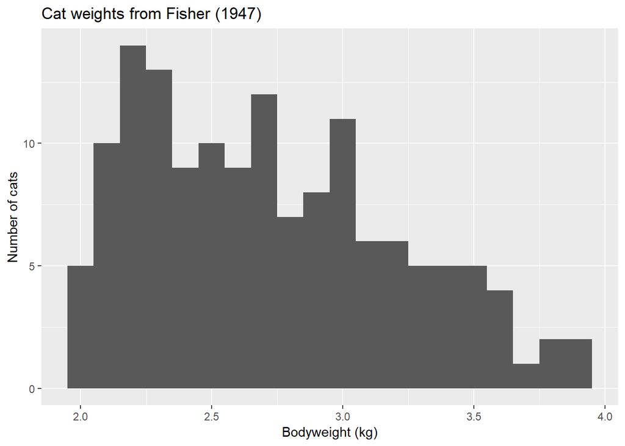

```r
cats.df = MASS::cats

ggplot(cats.df, aes(x = Bwt)) + geom_histogram(bins = 20) +
  xlab("Bodyweight (kg)") +
  ylab("Number of cats") +
  ggtitle("Cat weights from Fisher (1947)")
```

### 2.

#### b.

From the plots we can observe the following-

1. The general feeling towards Hilary Clinton is that of “very cold” with maximum values near 0 (25th percentile being 3) and mean being 43. The feeling for Hilary Clinton is somewhat polarizing as most values are concentrated towards the extreme ends.
2. The plot for Donald Trump is similar to Hilary Clinton’s, will most values on extreme ends thus showing the views towards Donald Trumpb being polar. Mean for Donald Trump is the lowest (40) showing the sentiment towards Trump being coldest.
3. Most values for Marco Rubio are midway between very cold and very hot, there are a lot of values for “very cold” as well.
4. The plot for Bernie Sanders is the most distributed of all the candidates, there are comparable values for “very cold”, “very hot” and midway between the two
5. The mean values for Sanders (~57) is the highest which shows the general feeling is the warmest towards him whereas the mean values is lowest for Trump (~40) which shows the feeling is coldest towards Trump

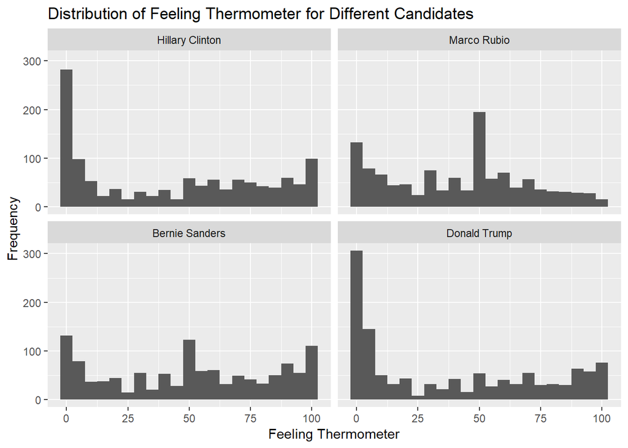

```r
anes_pilot_2016 = read.csv("C:\\Users\\singh\\Documents\\Acads\\EDA\\A2\\anes_pilot_2016.csv")

anes = anes_pilot_2016 %>% dplyr::select("fttrump", "fthrc", "ftsanders", "ftrubio", "immig_numb") %>% mutate(immig_numb = factor(immig_numb, levels = c(1,2,3,4,5,6,7), labels = c("Increased a lot", "Increased a moderate amount", "Increased a little", "Kept the same", "Decreased a little", "Decreased a moderate amount", "Decreased a lot")))

anes.long = gather(anes, key = "candidate", value="feeling_thermometer", c("fttrump", "fthrc", "ftsanders", "ftrubio"))

anes.long = anes.long[anes.long$feeling_thermometer <= 100,]

candidate.names = c("fttrump"="Donald Trump", "fthrc"="Hillary Clinton", "ftsanders"="Bernie Sanders", "ftrubio"="Marco Rubio")

ggplot(anes.long, aes(x = feeling_thermometer)) +
  geom_histogram(binwidth = 5) +
  facet_wrap(~ candidate, ncol = 2, labeller = as_labeller(candidate.names)) +
  xlab("Feeling Thermometer") +
  ylab("Frequency") +
  ggtitle("Distribution of Feeling Thermometer for Different Candidates")
```